# sorting slides

## Sorting

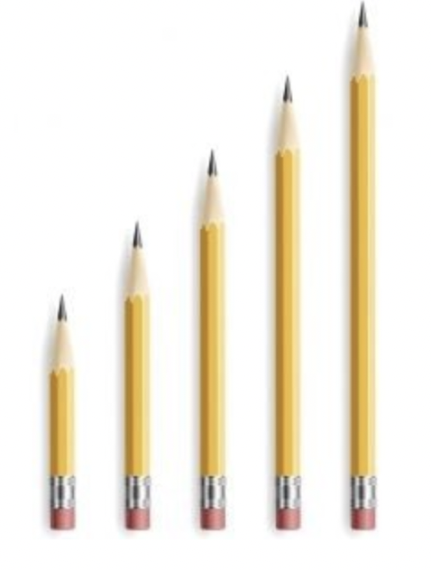

### Before we move on to Non-Linear Data Structures, we will look at Sorting

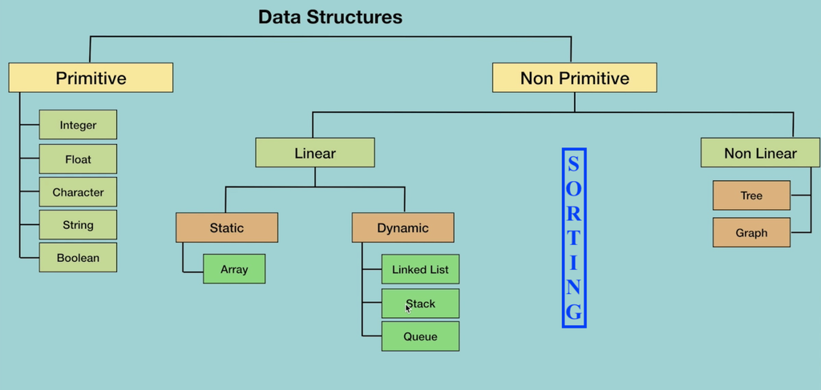

### Sorting

Sorting is any process of arranging items **systematically**, and has two common, yet distinct meanings:

- **ordering: arranging items in a sequence ordered by some criterion;**
- categorizing: grouping items with similar properties.

##### We will be concerned with the **former**

### Searching

- We have already looked at searching **unsorted** data
- We do this **very** often.
- Directly connected with **Sorting**

```python
def linearSearch( theValues, target ) :
  n = len( theValues )
  for i in range( n ) :
    # If the target is in the ith element, return True
    if theValues[i] == target:
      return True

  return False # If not found, return False.
```

```python
linearSearch([4,9,11,28, 104, 111, 293, 357, 471],28)
```

```python
linearSearch([4,9,11,28, 104, 111, 293, 357, 471],27)
```

#### How about searching sorted data?

##### Is it somehow easier?

#### Searching a sorted sequence

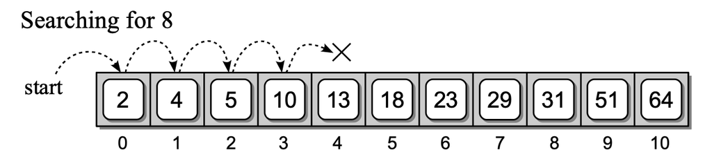

#### Searching a sorted sequence

- A linear search on a sorted sequence works the same way, except:
  - It is possible to terminate the search early when the value is not in the sequence instead of always having to perform a complete traversal.

```python
def sortedLinearSearch( theValues, item ) :
    n = len( theValues )
    for i in range(n):
        # If the target is found in the ith element, return True
        if theValues[i] == item :
            return True

        # If target is larger than the ith element, it's not in the sequence.
        elif theValues[i] > item :
            return False

    return False # The item is not in the sequence.
```

```
def sortedLinearSearch( theValues, item ) :
    n = len( theValues )
    for i in range(n):
        # If the target is found in the ith element, return True
        if theValues[i] == item :
            return True
        # If target is larger than the ith element, it's not there.
        elif theValues[i] > item :
            return False
    return False # The item is not in the sequence.
```

###### The efficiency of *sortedLinearSearch* comes only from quitting the search early for items that are not in the list.

```python
def sortedLinearSearch2( theValues, item ) :
    n = len( theValues )

    small = theValues[0] # the smallest in the array
    big = theValues[len(theValues)-1] # the largest in the array

    if (item < small) or (item > big):
        return False

    for i in range(n):
        # If the target is found in the ith element, return True
        if theValues[i] == item :
            return True
        # If target is larger than the ith element, it's not there.
        elif theValues[i] > item :
            return False
    return False # The item is not in the sequence.
```

```python
sortedLinearSearch2([4,9,11,28, 104, 111, 293, 357, 471],28)
```

```python
sortedLinearSearch([4,9,11,28, 104, 111, 293, 357, 471],28)
```

```
def sortedLinearSearch( theValues, item ) :
    n = len( theValues )
    for i in range(n):
        # If the target is found in the ith element, return True
        if theValues[i] == item :
            return True
        # If target is larger than the ith element, it's not there.
        elif theValues[i] > item :
            return False
    return False # The item is not in the sequence.
```

###### The efficiency of *sortedLinearSearch* comes only from quitting the search early for items that are not in the list.

```python
sortedLinearSearch([4,9,11,28, 104, 111, 293, 357, 471],27)
```

#### What is the time complexity of sortedLinearSearch?

#### Is there some way to reduce the time complexity when searching a sorted array?

#### Binary Search

##### Searching for 10 in the array below

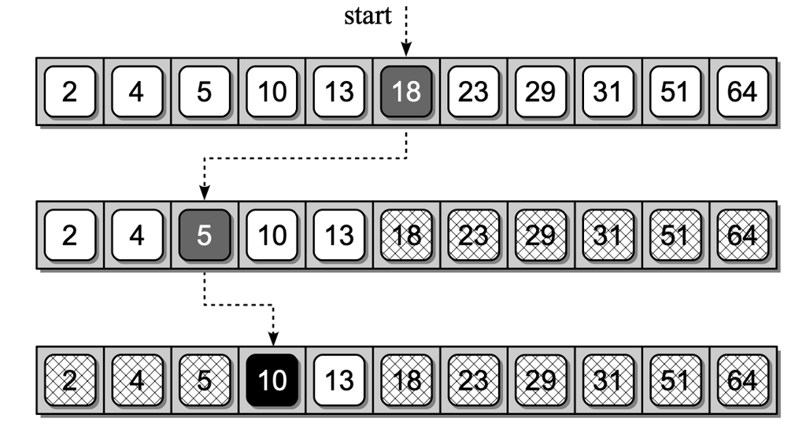

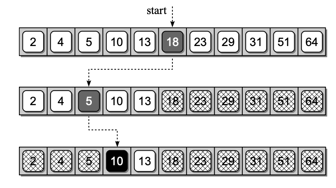

- Determine which element contains the middle entry.
- The middle entry contains 18, which is greater than our target of 10.
- We can discard the upper half of the array from consideration.
- Repeat the process on the lower half of the array.

```python
def binarySearch( theValues, target ) :
	# Start with the entire sequence of elements.
	low = 0
	high = len(theValues) - 1

	# Repeatedly subdivide the sequence in half until the target is found.
	while low <= high :
		# Find the midpoint of the sequence.
		mid = (high + low) // 2

		# Does the midpoint contain the target?
		if theValues[mid] == target :
			return True

		# Or does the target precede the midpoint?
		elif target < theValues[mid] :
			high = mid - 1

		# Or does it follow the midpoint?
		else :
			low = mid + 1

		# If the sequence cannot be subdivided further, we're done.

	return False
```

```python
binarySearch([4,9,11,28, 104, 111, 293, 357, 471],28)
```

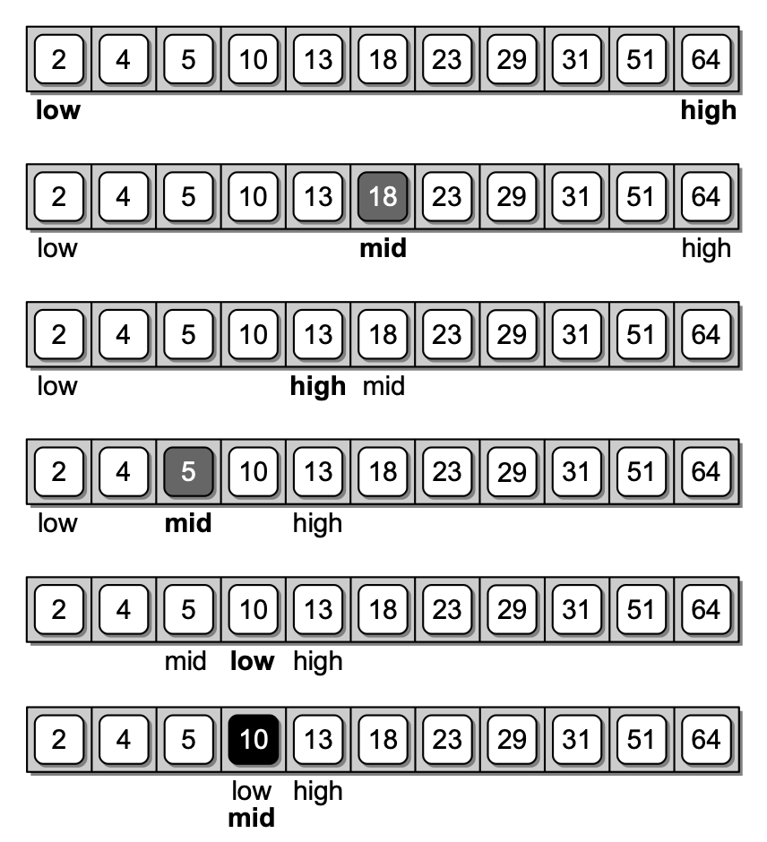

#### Binary Search Time Complexity

- At each step, we are discarding half the items.
- The time complexity is:

```python
def binarySearch( theValues, target ) :
	# Start with the entire sequence of elements.
	low = 0
	high = len(theValues) - 1

	cnt = 1
	# Repeatedly subdivide the sequence in half until the target is found.
	while low <= high :
		print("count:",cnt)
		cnt += 1

		# Find the midpoint of the sequence.
		mid = (high + low) // 2

		# Does the midpoint contain the target?
		if theValues[mid] == target :
			return True

		# Or does the target precede the midpoint?
		elif target < theValues[mid] :
			high = mid - 1

		# Or does it follow the midpoint?
		else :
			low = mid + 1

		# If the sequence cannot be subdivided further, we're done.

	return False
```

```python
binarySearch([4,9,11,28,104,111,293,357,471],28)
```

```python
binarySearch([4,9,11,28,104,111,293,357],28)
```

```python
binarySearch([4,9,11,28,104,111,293,357,471,500,600,700,800,900,1000],28)
```

```python
binarySearch([4,9,11,28,104,111,293,357,471,500,600,700,800,900,1000],4)
```

#### Binary Search is an example of a divide and conquer strategy,

#### which entails dividing a larger problem into smaller parts and conquering the smaller part.

$$ T(n) = \left\{ \begin{array}\\ c & \mbox{if } \ n = 1 \\ c+T(n/2) & \mbox{if } \ n > 1 \\ \end{array} \right.$$

$$ T(n) = \left\{ \begin{array}\\ c & \mbox{if } \ n = 1 \\ c+T(n/2) & \mbox{if } \ n > 1 \\ \end{array} \right.$$

$T(n) = c + T(n/2)) \implies T(n) = c + [c + T(n/4)] \implies T(n) = 2c + T(n/4)$

$T(n) = 2c + [c + T(n/8)] \implies T(n) = 3c + T(n/8)$

$T(n) = 3c + T(n/2^3)$

$T(n) = 3c + [c + T(n/2^4)] \implies T(n) = 4c + T(n/2^4)$

$$ T(n) = \left\{ \begin{array}\\ c & \mbox{if } \ n = 1 \\ c+T(n/2) & \mbox{if } \ n > 1 \\ \end{array} \right.$$

$T(n) = c + T(n/2)) \implies T(n) = c + [c + T(n/4)] \implies T(n) = 2c + T(n/4)$

$T(n) = 2c + [c + T(n/8)] \implies T(n) = 3c + T(n/8)$

$T(n) = 3c + T(n/2^3)$

$T(n) = 3c + [c + T(n/2^4)] \implies T(n) = 4c + T(n/2^4)$

##### When will we reach T(1) ?

##### Suppose $2^k = n,$

$T(n) = kc + T(n/2^k)$

$T(n) = (k+1)c$

##### That is $k = \log_2(n)$

$T(n) = O(\log n)$

### Sorting

- Sorting is the process of arranging or ordering a collection of items such that each item and its successor satisfy a prescribed relationship (for example, <=, >=).
  - integers, reals, student records,...
- the ordering of the items is based on the value of a **sort key**, which is of simple type (or a combination).

### Bubble Sort

- [ 6, 27, 14, 11, 4 ]

### Bubble Sort

- [ 6, 27, 14, 11, 4 ]
- Compare each consecutive pair, and swap if necessary.
- Pass 1:
  - Step 1: compare 6 and 27
  - in order, stay as they are [ 6, 27, 14, 11, 4 ]
  - Step 2: compare 27 and 14
  - out of order, swap them [ 6, 14, 27, 11, 4 ]
  - Step 3: compare 27 and 11
  - out of order, swap them [ 6, 14, 11, 27, 4 ]
  - Step 4: compare 27 and 4
  - out of order, swap them [ 6, 14, 11, 4, 27 ]
- What happens at the end of Pass 1?

### Bubble Sort...

- [ 6, 14, 11, 4, 27 ]
- Compare each consecutive pair, and swap if necessary.
- Pass 2:
  - Step 1: compare 6 and 14
  - in order, stay as they are [ 6, 14, 11, 4, 27 ]
  - Step 2: compare 14 and 11
  - out of order, swap them [ 6, 11, 14, 4, 27 ]
  - Step 3: compare 14 and 4
  - out of order, swap them [ 6, 11, 4, 14, 27 ]
  - Step 4?: compare 14 and 27?
- What happens at the end of Pass 2?

### Bubble Sort...

- [ 6, 11, 4, 14, 27 ]
- Compare each consecutive pair, and swap if necessary.
- Pass 3:
  - Step 1: compare 6 and 11
  - in order, stay as they are [ 6, 11, 4, 14, 27 ]
  - Step 2: compare 11 and 4
  - out of order, swap them [ 6, 4, 11, 14, 27 ]
  - Step 3: compare 11 and 14 needed?
- What happens at the end of Pass 3?

### Bubble Sort...

- [ 6, 4, 11, 14, 27 ]
- Compare each consecutive pair, and swap if necessary.
- Pass 4:
  - Step 1: compare 6 and 4
  - out of order, swap them [ 4, 6, 11, 14, 27 ]
  - Step 2: compare 6 and 11 needed?
- What happens at the end of Pass 4?

### Bubble Sort...

- What happens at the end of Pass 4?
- The items are sorted!
- How many passes did we need?
- How many steps in each pass?

https://visualgo.net/en/sorting

```python
def bubbleSort( mylist ):
  n = len( mylist )
  #print(n)

  # Perform n-1 bubble operations on the sequence
  for i in range( n - 1 ) :
    #print(i)

    # Bubble the largest item to the end.
    for j in range( n - 1 - i ) :
      print("comparing",mylist[j],mylist[j+1])

      if mylist[j] > mylist[j + 1] :
        # swap the j and j+1 items.
        print("swapping",mylist[j],mylist[j+1])
        tmp = mylist[j]
        mylist[j] = mylist[j + 1]
        mylist[j + 1] = tmp
    print("---------- end of pass:",i+1,mylist)

  return( mylist )
```

```python
bubbleSort([ 6, 27, 14, 11, 4 ])
```

#### Bubble Sort Time Complexity?

#### Bubble Sort Time Complexity

- inner loop: $(n - 1) + (n - 2) + ... +1$
- $\sum_{i = 1}^{(n-1)} i = (n - 1)n / 2 $
- $(n^2 - n)/2 = O(n^2)$

#### Bubble Sort Time Complexity

- What is the best case (example)?
- What is the worst case (example) ?
- What is taking time in Bubble Sort?

### Selection Sort

- First, **select** the smallest value
- Swap it with the one in the first position
- Next, select the next smallest value
- Swap it with the one in the second position
- ...

### Selection Sort ...

[ 6, 27, 14, 11, 4 ]

- Step 1:
  - Find the smallest value: 4
  - Swap it with: 6
  - [ 4, 27, 14, 11, 6 ]
- Step 2:
  - Find the smallest value: 6
  - Swap it with: 27
  - [ 4, 6, 14, 11, 27 ]

### Selection Sort ...

[ 4, 6, 14, 11, 27 ]

- Step 3:
  - Find the smallest value: 11
  - Swap it with: 14
  - [ 4, 6, 11, 14, 27 ]
- Step 4:
  - Find the smallest value: 14
  - It is already in place, do nothing!

```python
# Sorts a sequence in ascending order using the selection sort algorithm.
def selectionSort( mylist ):
    n = len( mylist )

    for i in range( n - 1 ):

        # Assume the ith element is the smallest.
        smallNdx = i

        # Determine if any other element contains a smaller value.
        for j in range( i + 1, n ):
            if mylist[j] < mylist[smallNdx] :
                smallNdx = j

            # Swap the ith value and smallNdx value only if the smallest value is
            # not already in its proper position. Some implementations omit testing
            # this condition and always swap the two values.
        print("minimum is:",mylist[smallNdx])
        if smallNdx != i :
            tmp = mylist[i]
            mylist[i] = mylist[smallNdx]
            mylist[smallNdx] = tmp
        else:
            print(mylist[i],"is already in place")
        print("\n")

    return(mylist)
```

```python
selectionSort([ 6, 27, 14, 11, 4 ])
```

#### Selection Sort in Action

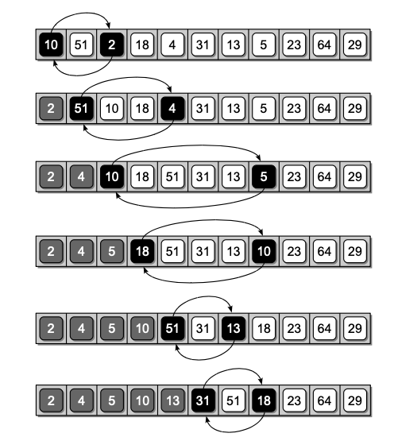

#### Selection Sort in Action...

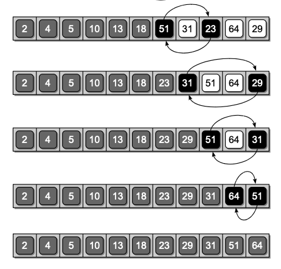

https://visualgo.net/en/sorting

#### Selection Sort Time Complexity?

#### Selection Sort Time Complexity

- inner loop: $(n - 1) + (n - 2) + ... +1$
- $\sum_{i = 1}^{(n-1)} i = (n - 1)n / 2 $
- $(n^2 - n)/2 = O(n^2)$
- Comparisons same as Bubble Sort, but fewer swaps.

#### Insertion Sort

- A collection of sorted items and a collection of items yet to be sorted.
- Both the sorted and unsorted collections within the same sequence structure.
- List of sorted values at the front of the sequence and picks the next unsorted value from the first of those yet to be positioned.

[4, 8, 6, 2]

[4 | 8, 6, 2 ] - First item is always sorted.

[4, 8 | 6 ,2 ] - 4 and 8 are in their right positions.

[4, 6, 8 | 2 ] - 4, 6 and 8 are sorted

[2, 4, 6, 8 ] - Fully sorted

#### Insertion Sort

[figure not shown]

```python
# Sorts a sequence in ascending order using the insertion sort algorithm.
def insertionSort( theSeq ):
  n = len( theSeq )

  # Starts with the first item as the only sorted entry.
  for i in range( 1, n ) :
    # Save the value to be positioned.
    value = theSeq[i]
    print("deciding for position",i,"incoming value:",value)

    # Find the position where value fits in the ordered part of the list.
    pos = i

    while pos > 0 and value < theSeq[pos - 1] :
      # Shift the items to the right during the search.
      print(value," < ", theSeq[pos - 1])
      theSeq[pos] = theSeq[pos - 1]
      print('moving',theSeq[pos -1],"to position",pos)
      pos -= 1

    # Put the saved value into the open slot.
    theSeq[pos] = value
    print("found pos:",pos,"for value:",value)
    print("sorted subseq:",theSeq[0:i+1],"\nremaining:",theSeq[i+1:],"\n")

  return( theSeq )
```

```python
insertionSort([4,8,6,2])
```

#### Insertion Sort

- A collection of sorted items and a collection of items yet to be sorted.
- Both the sorted and unsorted collections within the same sequence structure.
- List of sorted values at the front of the sequence and picks the next unsorted value from the first of those yet to be positioned.

#### Insertion Sort

- The insertionSort() function starts by assuming the first item is in its proper position.
- Next, an iteration is performed over the remaining items so each value can be inserted into its proper position *within the sorted portion* of the sequence.
- The ordered portion of the sequence is at the front while those yet to be inserted are at the end.
- The $i$ loop index variable marks the separation point between the two parts.

#### Insertion Sort

- The inner loop is used to *find the insertion point* within the sorted sequence..
- and at the same time, *shifts the items down* to make room for the next item.

https://visualgo.net/en/sorting

#### Time Complexity of Insertion Sort ?

#### Time Complexity of Insertion Sort

- At most (n - 1) comparisons and (n - 1) shifts for the last element
- At most (n - 2) comparisons and (n - 2) shifts for the second to last element.

$\implies 2 * \sum_i^{(n - 1)} i = 2(n - 1)n/2 = n(n - 1)$

$\implies T(n) = O(n^2)$

#### Merge Sort

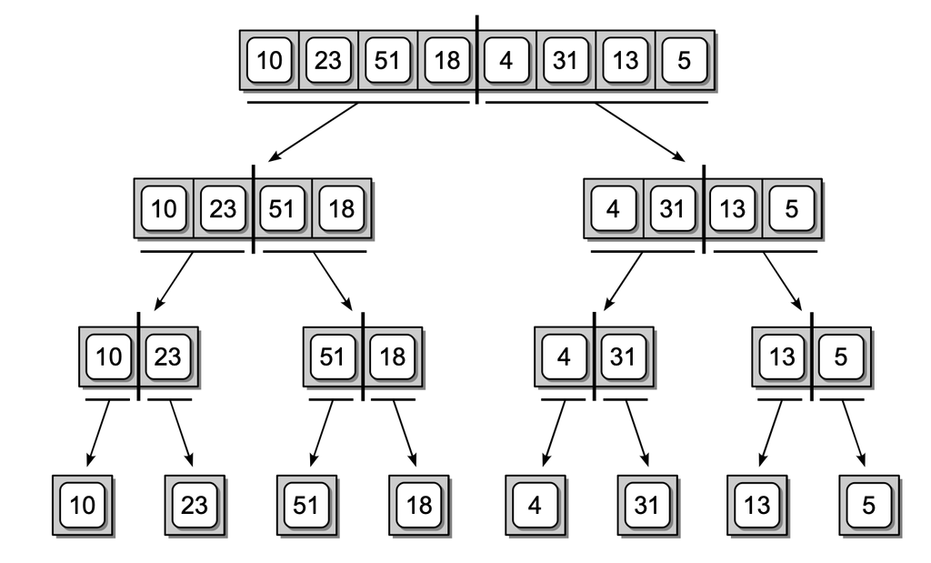

#### Merge Sort

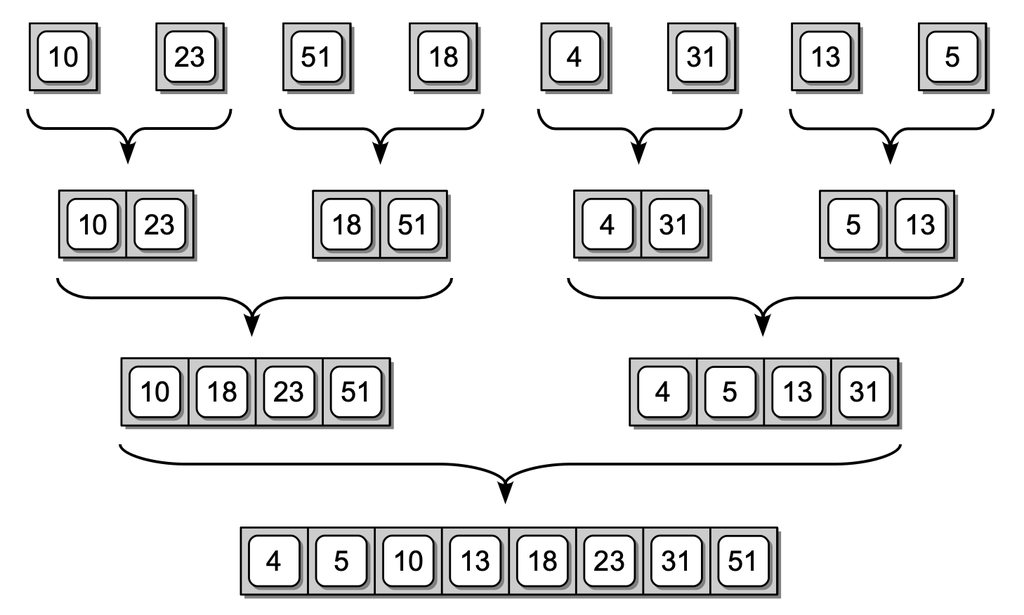

#### Merge Sort

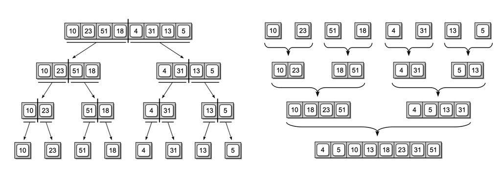

#### Merge Sort

- Two major steps:
  - Dividing the list into smaller and smaller sublists
  - Merging the sublists to form a sorted list
- It is convenient to use *recursion!*

#### Merge Sort

- Let's first understand, how would we merge two sorted lists?
  - [ 3, 12, 26, 31, 48 ] and [ 2, 14, 21 ] ; ans = [ ]
  - Compare 2 and 3; 2 is the least of all.
  - [ 3, 12, 26, 31, 48 ] and [ 14, 21 ] ; ans = [ 2 ]
  - Compare 3 and 14; 3 is the least of the rest.
  - [ 12, 26, 31, 48 ] and [ 14, 21 ] ; ans = [ 2, 3 ]

#### Merge Sort

- (cont'd) Let's first understand, how would we merge two sorted lists?
  - Compare 12 and 14; 12 is the least of the rest.
  - [ 26, 31, 48 ] and [ 14, 21 ] ; ans = [ 2, 3, 12 ]
  - Compare 26 and 14; 14 is the least of the rest.
  - [ 26, 31, 48 ] and [ 21 ] ; ans = [ 2, 3, 12, 14 ]
  - Compare 26 and 21; 21 is the least of the rest.
  - [ 26, 31, 48 ] and [ ] ; ans = [ 2, 3, 12, 14, 21 ]

```python
# Merges the two sorted subsequences: [left..right) [right..end)
# using the tmpArray for intermediate storage.

def mergeSortedSubseq( theSeq, left, right, end, tmpArray ):
  # Initialize two subsequence index variables.
  a=left
  b=right

  # Initialize an index variable for the resulting merged array.
  m=0

  # Merge the two sequences together until one is empty.
  while a < right and b < end:
    if theSeq[a] < theSeq[b] :
      tmpArray[m] = theSeq[a]
      a += 1
    else :
      tmpArray[m] = theSeq[b]
      b += 1

    m += 1

  # If the left subsequence contains more items append them to tmpArray.
  while a < right :
    tmpArray[m] = theSeq[a]
    a += 1
    m += 1

  # Or if right subsequence contains more, append them to tmpArray.
  while b < end:
    tmpArray[m] = theSeq[b]
    b += 1
    m += 1

  # Copy the sorted subsequence back into the original sequence structure.
  for i in range(end-left):
    theSeq[i+left] = tmpArray[i]
```

```python
# Sorts a subsequence in ascending order using merge sort.

def recMergeSort( theSeq, first, last, tmpArray ):
  # The elements that comprise the subsequence are indicated
  # by the range [first...last]. tmpArray is temporary storage used in
  # the merging phase of the merge sort algorithm.

  # Check the base case: the subsequence contains a single item.
  if first == last :
    return;
  else :
    # Compute the mid point.
    mid = (first + last) // 2
    print("mid(index):",mid,"mid(elem)",theSeq[mid])

  # Split the sequence and perform the recursive step.
  recMergeSort( theSeq, first, mid, tmpArray )
  recMergeSort( theSeq, mid+1, last, tmpArray )

  print("merging",theSeq[first],"--",theSeq[mid],"and",theSeq[mid+1],"--",theSeq[last])
  # Merge the two ordered subsequences.
  mergeSortedSubseq( theSeq, first, mid+1, last+1, tmpArray )
```

```python
# Sorts an array or list in ascending order using merge sort.

def mergeSort( theSeq ):
    n = len( theSeq )
    # Create a temporary array for use when merging subsequences.
    tmpArray = [-1]*n
    # Call the private recursive merge sort function.
    recMergeSort( theSeq, 0, n-1, tmpArray )
    return(tmpArray)
```

```python
mergeSort([2,8,4,6,1,22])
```

$$ T(n) = \left\{ \begin{array}\\ 1 & \mbox{if } \ n = 1 \\ 2T(n/2) + n & \mbox{if } \ n > 1 \\ \end{array} \right.$$

$$ T(n) = \left\{ \begin{array}\\ 1 & \mbox{if } \ n = 1 \\ 2T(n/2) + n & \mbox{if } \ n > 1 \\ \end{array} \right.$$

$T(n) = 2T(n/2) + n $

$T(n) = 2[2T(\frac{n}{4})+\frac{n}{2}] + n$

$T(n) = 4T(\frac{n}{4})+ n + n$

$T(n) = 4T(\frac{n}{4})+ 2n$

$$ T(n) = \left\{ \begin{array}\\ 1 & \mbox{if } \ n = 1 \\ 2T(n/2) + n & \mbox{if } \ n > 1 \\ \end{array} \right.$$

$T(n) = 4T(\frac{n}{4})+ 2n$

$T(n) = 4[2T(\frac{n}{8}) + \frac{n}{4}] + 2n$

$T(n) = 8T(\frac{n}{8}) + n + 2n = 8T(\frac{n}{8}) + 3n$

$T(n) = 2^3T(\frac{n}{2^3}) + 3n$

$$ T(n) = \left\{ \begin{array}\\ 1 & \mbox{if } \ n = 1 \\ 2T(n/2) + n & \mbox{if } \ n > 1 \\ \end{array} \right.$$

$T(n) = 2^3T(\frac{n}{2^3}) + 3n$

Let $2^k = n$,

$T(n) = 2^kT(\frac{n}{2^k}) + kn$

$T(n) = nT(1) + kn$

Now, $T(1) = 1\ and\ k = \log_2(n)$

$T(n) = n + (\log_2 n) n $

$T(n) = O(n\log n)$

https://visualgo.net/en/sorting

#### Can we do a variation of mergesort without using tmpArray?

#### QuickSort

- The quicksort algorithm also uses the divide and conquer strategy.
- Unlike the merge sort, (which splits the sequence of keys at the midpoint), the quick sort partitions the sequence by dividing it into two segments based on a selected **pivot key.**
- Does not require temporary storage.

#### QuickSort

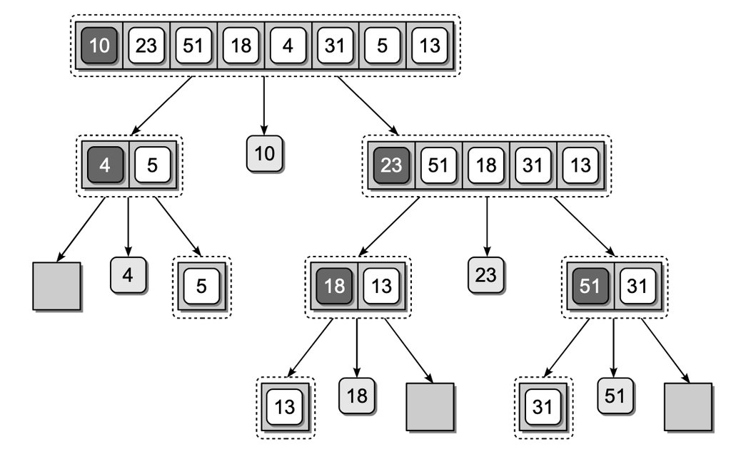

#### QuickSort

1. The first key is selected as the pivot, **p**. The pivot value is used to partition the sequence into two segments or subsequences, **L** and **G**, such that L contains all keys less than the p and G contains all keys greater than or equal to p.
2. The algorithm is then applied recursively to both L and G. The recursion continues until the base case is reached, which occurs when the sequence contains fewer than two keys.
3. The two segments and the pivot value are merged to produce a sorted sequence. This is accomplished by copying the keys from segment L back into the original sequence, followed by the pivot value and then the keys from segment G. After this step, the pivot key will end up in its proper position within the sorted sequence.

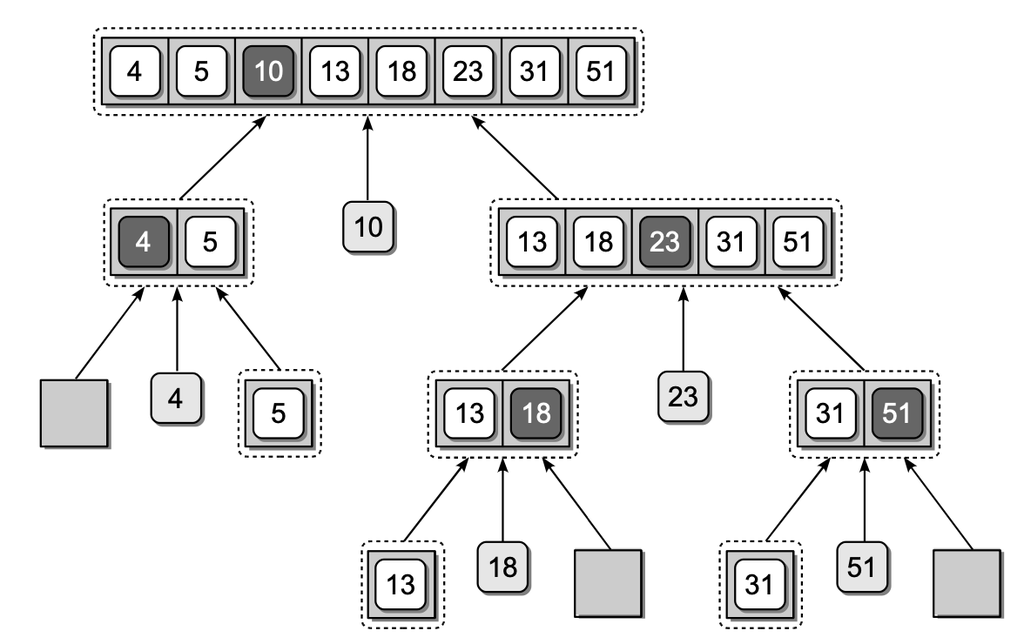

## Charles Antony Richard Hoare (Turing Award, 1980)

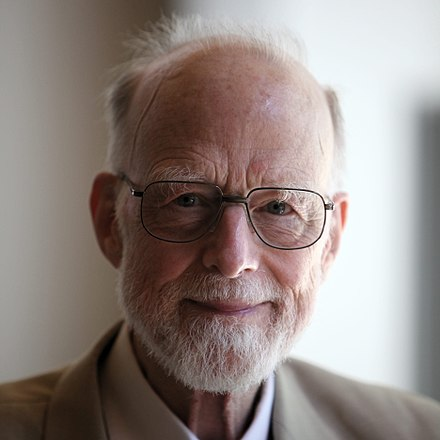

https://www.youtube.com/watch?v=pJgKYn0lcno

#### QuickSort

- The quicksort algorithm was developed in 1959 by Tony Hoare while he was a visiting student at Moscow State University.
- At that time, Hoare was working on a machine translation project for the National Physical Laboratory.
- As a part of the translation process, he needed to sort the words in Russian sentences before looking them up in a Russian-English dictionary, which was in alphabetical order on magnetic tape.
- He got the idea about Quicksort.
- On return to England, he was asked to write code for Shellsort.
- Hoare mentioned to his boss that he knew of a faster algorithm and his boss bet sixpence that he did not.
- His boss ultimately accepted that he had lost the bet.
- Later, Hoare learned about ALGOL and its ability to do recursion that enabled him to publish the code in Communications of the Association for Computing Machinery (ACM), the premier computer science journal of the time.

```python
def partitionSeq(arr, low, high):
    i = (low-1)         # index of smaller element
    pivot = arr[high]   # pivot
    print("  pseq:",arr[low],"...","pivot:",arr[high])

    for j in range(low, high):

        if arr[j] <= pivot:

            # increment index of smaller element
            i = i+1
            print("  pseq:",arr[j],"<",pivot,"incrementing i to:",i)
            arr[i], arr[j] = arr[j], arr[i]

    print("\n  pseq:swapping pivot",pivot,"into position:",i+1)
    arr[i+1], arr[high] = arr[high], arr[i+1]
    print("  pseq:",arr)
    return (i+1)
```

```python
partitionSeq([4,8,6,2,5],0,4)
```

```python
# The recursive implementation using virtual segments.
def recQuickSort( theSeq, first, last ):
    # Check the base case.
    print("in recQS:",theSeq,"first",first,"last",last)
    if first >= last :
        return
    else :
        # Save the pivot value.
        pivot = theSeq[last]
        print("  pivot:",pivot)
        # Partition the sequence and obtain the pivot position.
        pos = partitionSeq( theSeq, first, last )
        # Repeat the process on the two subsequences.
        #print("  calling 1:",theSeq[first:pos])
        recQuickSort( theSeq, first, pos-1)
        #print("  return 1:",theSeq[first:pos])
        #print("  --------\ncalling 2:",theSeq[pos+1:last])
        recQuickSort( theSeq, pos + 1, last)
        #print("  return 2:",theSeq[pos+1:last])
    print("\n sorted seq:",theSeq)
```

```python
recQuickSort([6,8,4,43,5,21],0,5)
```

```python
# Sorts an array or list using the recursive quick sort algorithm.
def quickSort( theSeq ):
    n = len( theSeq )
    recQuickSort( theSeq, 0, n-1 )
```

```python
quickSort([4,8,7,2,6,31,29,17,1])
```

- Quicksort gained widespread adoption: for example, in Unix as the default library sort subroutine (`qsort`).
- Also in the reference implementation of Java.
- In 2009, Vladimir Yaroslavskiy proposed a new Quicksort implementation using two pivots instead of one. http://www.kriche.com.ar/root/programming/spaceTimeComplexity/DualPivotQuicksort.pdf?i=1
- Yaroslavskiy's Quicksort has been chosen as the new default sorting algorithm in Oracle's Java 7 runtime library after extensive empirical performance tests.

#### QuickSort Time Complexity

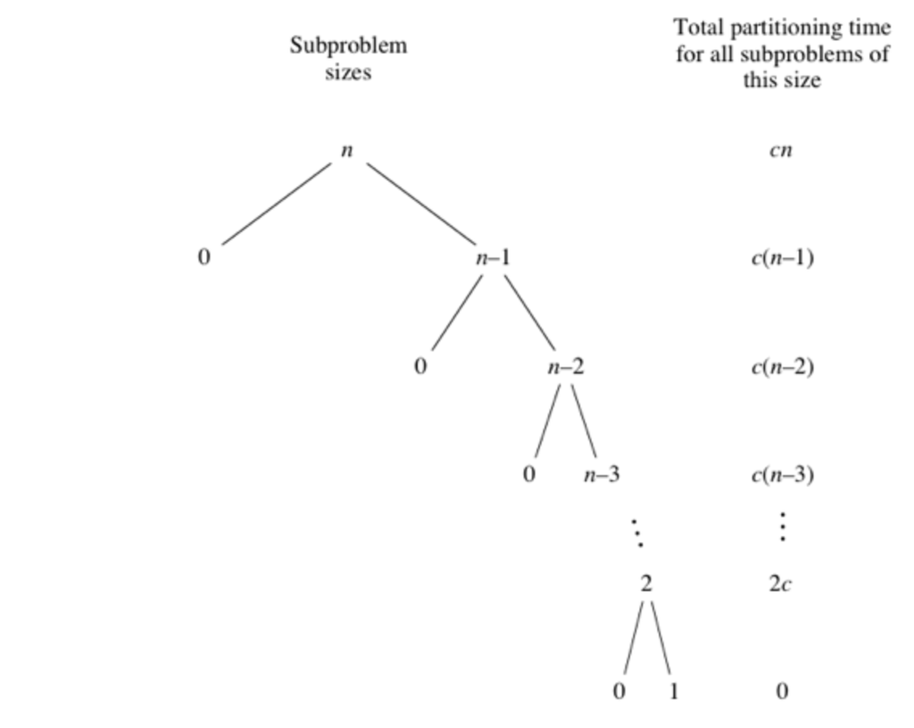

#### QuickSort Time Complexity

$T(n) = c(n - 1) + c(n - 2) + ... + 3 + 2 + 1$

$T(n) = O(n^2)$

#### QuickSort

- The quick sort algorithm has an average or expected time of $O(n\log n)$.
- The choice of the pivot is crucial.
- While mergesort uses a temporary array (extra storage), quicksort does not.
- Earlier versions of Python used quick sort to implement the `sort()` method of the list structure.
  - In the current version of Python, a hybrid algorithm that combines the insertion and merge sort algorithms is used instead.

## Sorting

### Can we do better than $O(n \log n)$?

#### Sorting based on comparisons

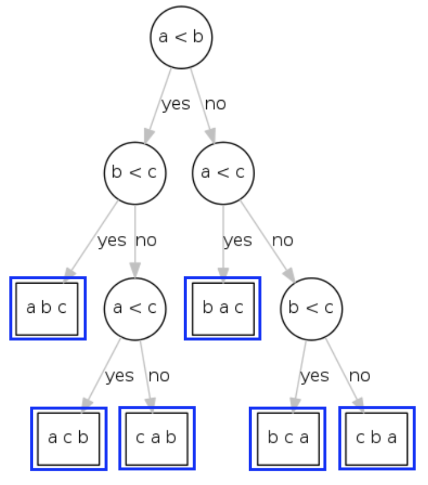

#### Sorting based on comparisons

- For 3 elements, how many possibilities?
- For $n$ elements, how many possibilities?

#### Sorting based on comparisons

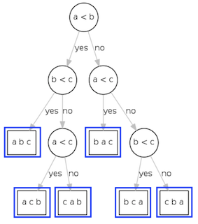

- One of $N!$ permutations have to be selected.
- That requires how many pairwise comparisons?
- Depth of the decision structure is...?
  - Level 0: 1
  - Level 1: 2
  - Level 2: 4
  - Level 3: 8

#### Sorting based on comparisons

- At level $k$, I have $N!$ possibilities

  $\implies 2^k \geq N!$

  $\implies k \geq \log_2(N!)$

  $N! = N\times(N - 1)\times(N - 2)\times...\times\ 1 $

  $N! \leq N\times N\times....N$ (N times)

#### Sorting based on comparisons

- At level $k$, I have $N!$ possibilities

  $\implies 2^k \geq N!$

  $\implies k \geq \log_2(N!)$

  $N! = N\times(N - 1)\times(N - 2)\times...\times\ 1 $

  $N! \leq N\times N\times....N$ (N times)

  $\implies N! \leq N^N$

  $\implies \log(N!) \leq log (N^N) = N(\log N)$
- $k \approx N(\log N)$

#### Sorting based on comparisons

- Stirling's approximation
  - $\log(N!) = N\log N - O(N) + O(\log N)$
- This establishes that it takes **at least** $N\log N$ time.
- This is denoted by: $\Omega(N\log N)$

#### Is there another way to improve the speed of sorting?

### Sorting

- We can however do better with **distribution** sorting.
- The idea is to first partition the input set into several buckets,...
- and then independently sort the buckets and write the sorted buckets to an output array.

#### Radix Sort / Bucket Sort

- a fast distribution sorting algorithm
- when sorting integer keys,
  - the individual digits of the keys are compared from least significant to most significant.
- can be used to sort many types of keys, including positive integers, strings, and floating-point values.

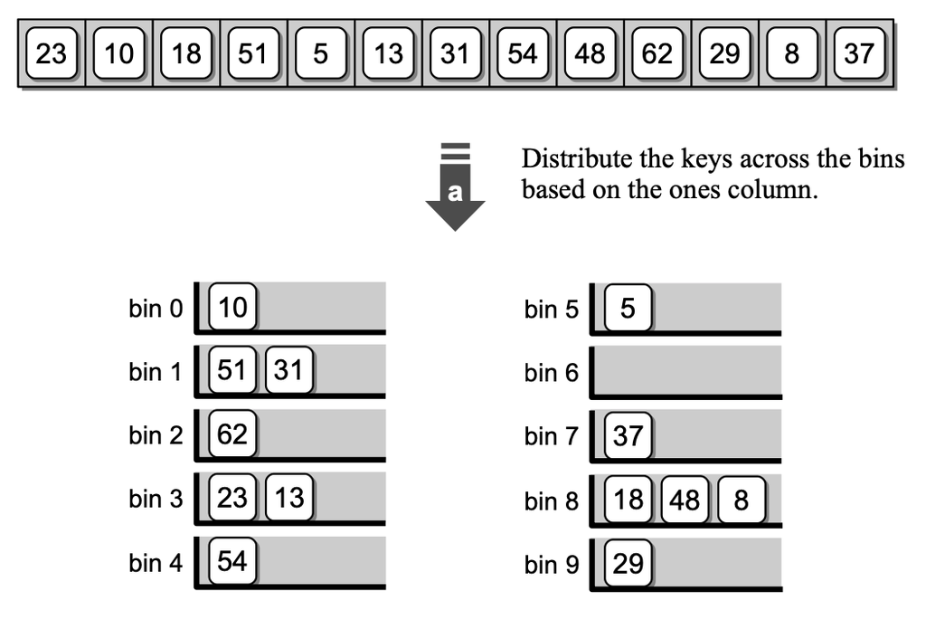

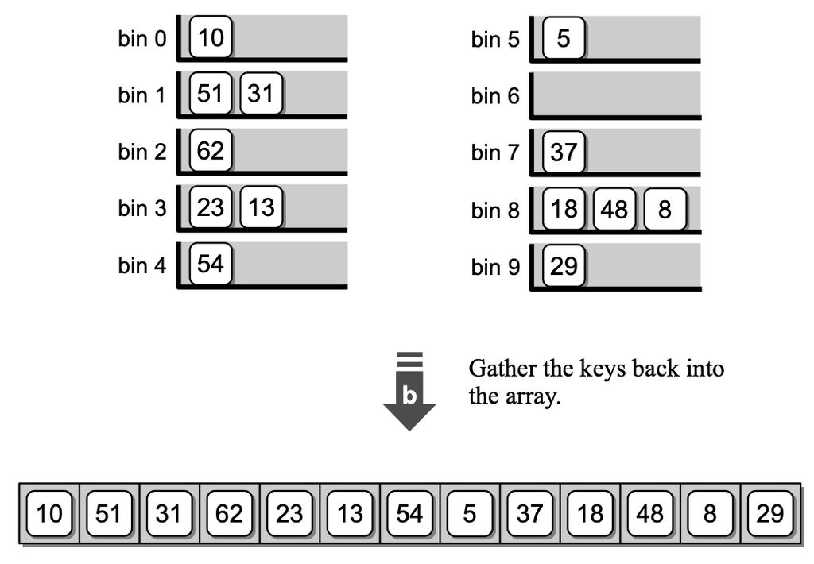

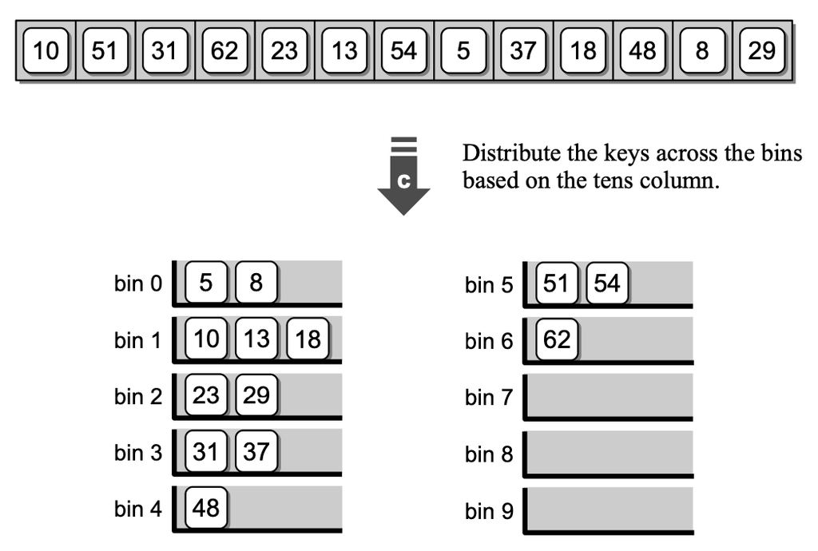

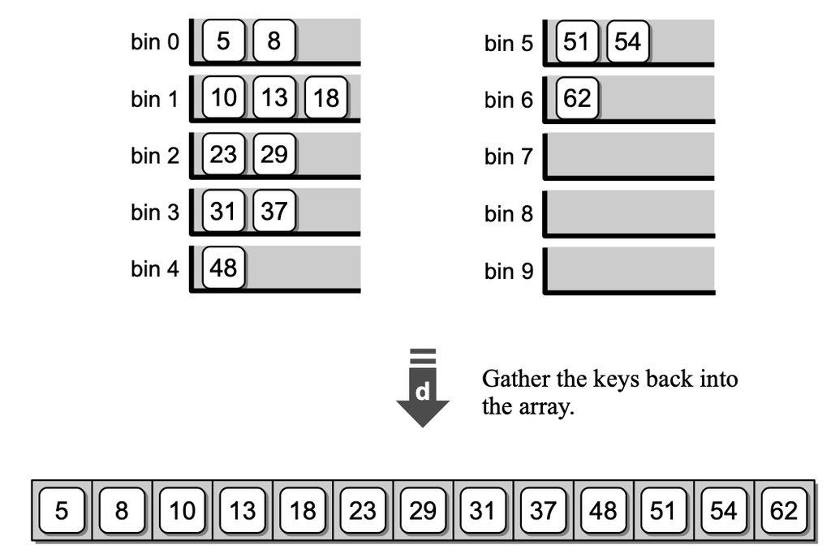

#### If there were more digits, this would have to be repeated more times.

```python
# Implementation of the Queue ADT using a linked list.
class lQueue :

  # Creates an empty queue.
  def __init__( self ):
    self._qhead = None
    self._qtail = None
    self._count = 0

  # Returns True if the queue is empty.
  def isEmpty( self ):
    return self._qhead is None

  # Returns the number of items in the queue.
  def __len__( self ):
    return self._count

  # Adds the given item to the queue.
  def enqueue( self, item ):
    node = _QueueNode( item )

    if self.isEmpty() :
      self._qhead = node
    else :
      self._qtail.next = node

    self._qtail = node
    self._count += 1

  # Removes and returns the first item in the queue.
  def dequeue( self ):
    assert not self.isEmpty(), "Cannot dequeue from an empty queue."
    node = self._qhead

    if self._qhead is self._qtail :
      self._qtail = None

    self._qhead = self._qhead.next
    self._count -= 1
    return node.item

  # Private storage class for creating the linked list nodes.
class _QueueNode( object ):
  def __init__( self, item ):
    self.item = item
    self.next = None
```

```python
#### Sorts a sequence of positive integers using the radix sort algorithm.

def radixSort( intList, numDigits ):

    # Create a list of queues to represent the bins.
    binArray = [-1]*10
    for k in range( 10 ):
        binArray[k] = lQueue()

    # The value of the current column.
    column = 1

    numops = 0

    # Iterate over the number of digits in the largest value.
    for d in range( numDigits ):
        # Distribute the keys across the 10 bins.
        for key in intList :
            digit = (key // column) % 10
            binArray[digit].enqueue( key )
            numops += 1

        # Gather the keys from the bins and place them back in intList.
        i=0
        for bin in binArray :
            while not bin.isEmpty() :
                intList[i] = bin.dequeue()
                i += 1
        # Print intlist
        print("after digit",d,":",intList)
        # Advance to the next column value.
        column *= 10

        print("# operations: ",numops)

    return(intList)
```

```python
radixSort([11,8,3,31,97, 21, 65, 55],2)
```

#### Radix Sort Time Complexity

- A sequence of $n$ keys in which each key contains $d$ components in the largest key value
  - $d$ is the number of digits.
- Each component contains a value between 0 and $k−1$.
  - 0 -- 9 ($k = 10$)
- Linked-list implementation of Queue, so `enqueue()` is $O(1)$, `dequeue()` is $O(1)$ anyway.

#### Radix Sort Time Complexity ...

- Creating $k$ queues takes $O(k)$ time.
- Distribution of $n$ keys over $k$ queues takes $O(n)$ time.
- Gathering of $n$ keys from $k$ queues takes $O(n)$ time.
- Distribution and gathering operations performed $d$ times ($2dn$) = $O(dn)$
- In practice, $k$ and $d$ are constants
  - $\therefore T(n) = O(n)$